# Machine Learning - Course Project

# The Project

### Description

One thing that people regularly do is quantify how much of a particular activity they do, but they rarely quantify how well they do it. In this project, the goal is to use data from accelerometers on the belt, forearm, arm, and dumbell of 6 participants to predict the matter in which they did the exercise with the outcome variable “classe”.

### Steps

The following steps were taken to get to the solution for this project:

- Getting and cleaning the data
- Exploratory data analysis
- Preprocessing the data
- Machine learning
- Final Model

### Executive Summary

- Some steps were taken to remove columns with too many missing values
- PCA was performed to reduce the number of variables to 38 variables.
- Final model chosen was a Gradient Boosting Model with accuracy 95% on the training set and 93% on the validation set.

# Getting and cleaning the data

### The Program

```r
# Load the data
Training_Raw1 <- read.csv("C:/Coursera/8. Machine Learning/Raw Data/pml-training.csv")
Testing_Raw <- read.csv("C:/Coursera/8. Machine Learning/Raw Data/pml-testing.csv")

# Check dimensions of the data
dim(Training_Raw1)
```

```
## [1] 19622   160
```

```r
dim(Testing_Raw)
```

```
## [1]  20 160
```

```r
# Convert all variables to numeric
for (i in 8:(dim(Training_Raw1)[2] - 1)) {
    Training_Raw1[, i] <- as.numeric(Training_Raw1[, i])
    Testing_Raw[, i] <- as.numeric(Testing_Raw[, i])
}

# Create a validation set, I'm keeping the test set provided as my out of
# time sample
library(caret)
set.seed(1254)
inTrain = createDataPartition(Training_Raw1$classe, p = 0.75)[[1]]
Training_Raw = Training_Raw1[inTrain, ]
Validation_Raw = Training_Raw1[-inTrain, ]

# Check for missing values
check1 <- complete.cases(Training_Raw)
check2 <- complete.cases(Testing_Raw)
check3 <- complete.cases(Validation_Raw)

# dim(check1) dim(check2) dim(check3)

# Remove columns where more than 75% are missing
col_filter <- sapply(Training_Raw, function(x) sum(is.na(x)))
col_filter2 <- (col_filter > (dim(Training_Raw))[1] * 0.75)
col_filter3 <- as.numeric(which(unlist(col_filter2)))


Training_Raw2 <- Training_Raw[, -col_filter3]
Testing_Raw2 <- Testing_Raw[, -col_filter3]
Validation_Raw2 <- Validation_Raw[, -col_filter3]

# Impute those remaining with missing values
for (i in 1:ncol(Training_Raw2)) {
    Training_Raw2[is.na(Training_Raw2[, i]), i] <- mean(Training_Raw2[, i],
        na.rm = TRUE)
    Testing_Raw2[is.na(Testing_Raw2[, i]), i] <- mean(Training_Raw2[, i], na.rm = TRUE)
    Validation_Raw2[is.na(Validation_Raw2[, i]), i] <- mean(Training_Raw2[,
        i], na.rm = TRUE)
}
```

# Pre-processing & Exploratory Data Analysis

### The Program

```r
# Look at variables with correlation more than 0.6 to the response
table(Training_Raw2$classe)
```

```
##
##    A    B    C    D    E
## 4185 2848 2567 2412 2706
```

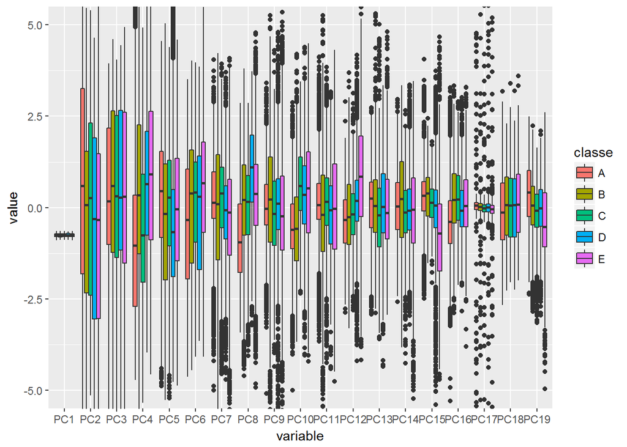

```r
# summary(Training_Raw2)

# Create new variables with PCA
set.seed(1254)
Pre_proc <- preProcess(Training_Raw2[, -93], method = "pca")

# Create data sets with PCA variables
PCA_Train <- data.frame(predict(Pre_proc, Training_Raw2[, -93]), Training_Raw2[,
    93])
PCA_Test <- data.frame(predict(Pre_proc, Testing_Raw2[, -93]), Testing_Raw2[,
    93])
PCA_Valid <- data.frame(predict(Pre_proc, Validation_Raw2[, -93]), Validation_Raw2[,
    93])

colnames(PCA_Train)[42] <- "classe"
colnames(PCA_Test)[42] <- "classe"
colnames(PCA_Valid)[42] <- "classe"

# Look at PCA variables with a Boxplot
PCA_Train1 <- PCA_Train[, 4:42]
PCA_Train1a <- PCA_Train1[, c(1:19, 39)]
PCA_Train1b <- PCA_Train1[, c(20:39)]

require(reshape2)
df.m <- melt(PCA_Train1a, id.var = "classe")
df.m2 <- melt(PCA_Train1b, id.var = "classe")

require(ggplot2)
ggplot(data = df.m, aes(x = variable, y = value)) + geom_boxplot(aes(fill = classe)) +
    coord_cartesian(ylim = c(-5, 5))
```

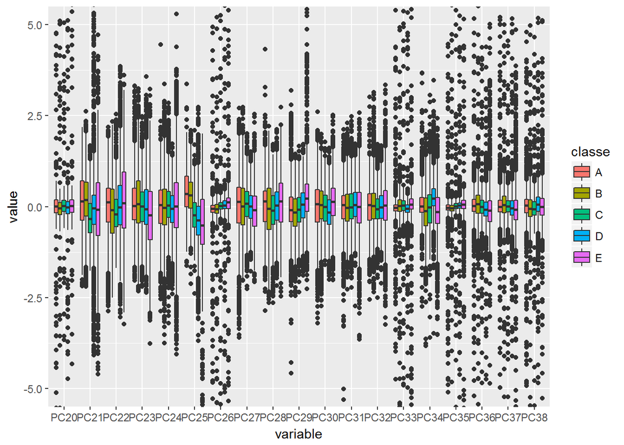

```r
ggplot(data = df.m2, aes(x = variable, y = value)) + geom_boxplot(aes(fill = classe)) +
    coord_cartesian(ylim = c(-5, 5))
```

```r
# Factor Variable - User
prop.table(with(PCA_Train, table(user_name, classe)), 1)
```

```
##           classe
## user_name          A         B         C         D         E
##   adelmo   0.3015657 0.2021784 0.1855003 0.1347856 0.1759700
##   carlitos 0.2710686 0.2224153 0.1572546 0.1537793 0.1954822
##   charles  0.2505660 0.2056604 0.1566038 0.1818868 0.2052830
##   eurico   0.2785527 0.1926765 0.1608544 0.1922406 0.1756757
##   jeremy   0.3482178 0.1484528 0.1923228 0.1500196 0.1609871
##   pedro    0.2438163 0.1898031 0.1943463 0.1797072 0.1923271
```

```r
# Exclude any other unnecessary variables
PCA_Train <- PCA_Train[, c(1, 4:42)]
PCA_Test <- PCA_Test[, c(1, 4:42)]
PCA_Valid <- PCA_Valid[, c(1, 4:42)]
```

### Summary

All numeric variables in the data can be summarised by 38 PCA variables. Of these 38 variables, there seems to be a clear indication that at least 12 of these variables show some relation to the response.

The factor variable “user_name” shows that the particular user also has some effect on the response. This might be due to preference of the user.

# Machine Learning

### Strategy

My strategy is build the following models:

- Multinomial GLM
- Decision Tree
- Gradient Boosting Model

I will then evaulate each model separately. The model that performs at the highest level of accuracy conditional that the training and validation results are within 5%-points from another, is the model that I choose.

Do note that all models should be built within reasonable time, due to this, I have not considered a Random Forest model.

### The Program

```r
# Multinomial GLM install.packages('nnet')
library(nnet)
library(caret)

set.seed(5463)
glm_pca <- nnet::multinom(formula = classe ~ ., data = PCA_Train)

# Decision Tree
set.seed(9216)
tree_pca <- train(classe ~ ., method = "rpart", data = PCA_Train)

# Gradient Boosting Model
set.seed(78234)
boost_pca <- train(classe ~ ., method = "gbm", data = PCA_Train)
```

```r
# Evaluate Models Multinomial GLM
train_glm <- predict(glm_pca, newdata = PCA_Train)
confusionMatrix(train_glm, PCA_Train$classe)
```

```
## Confusion Matrix and Statistics
##
##           Reference
## Prediction    A    B    C    D    E
##          A 4156  129    0    0    0
##          B   29 2421  145    1    0
##          C    0  287 2245  202    1
##          D    0   11  164 2076  116
##          E    0    0   13  133 2589
##
## Overall Statistics
##
##                Accuracy : 0.9164
##                  95% CI : (0.9118, 0.9208)
##     No Information Rate : 0.2843
##     P-Value [Acc > NIR] : < 2.2e-16
##
##                   Kappa : 0.8941
##  Mcnemar's Test P-Value : NA
##
## Statistics by Class:
##
##                      Class: A Class: B Class: C Class: D Class: E
## Sensitivity            0.9931   0.8501   0.8746   0.8607   0.9568
## Specificity            0.9878   0.9853   0.9597   0.9764   0.9878
## Pos Pred Value         0.9699   0.9326   0.8208   0.8771   0.9466
## Neg Pred Value         0.9972   0.9648   0.9731   0.9728   0.9902
## Prevalence             0.2843   0.1935   0.1744   0.1639   0.1839
## Detection Rate         0.2824   0.1645   0.1525   0.1411   0.1759
## Detection Prevalence   0.2911   0.1764   0.1858   0.1608   0.1858
## Balanced Accuracy      0.9904   0.9177   0.9171   0.9185   0.9723
```

```r
valid_glm <- predict(glm_pca, newdata = PCA_Valid)
confusionMatrix(valid_glm, PCA_Valid$classe)
```

```
## Confusion Matrix and Statistics
##
##           Reference
## Prediction    A    B    C    D    E
##          A 1387   44    1    0    0
##          B    8  826   50    0    0
##          C    0   77  734   66    3
##          D    0    2   66  682   43
##          E    0    0    4   56  855
##
## Overall Statistics
##
##                Accuracy : 0.9144
##                  95% CI : (0.9062, 0.922)
##     No Information Rate : 0.2845
##     P-Value [Acc > NIR] : < 2.2e-16
##
##                   Kappa : 0.8916
##  Mcnemar's Test P-Value : NA
##
## Statistics by Class:
##
##                      Class: A Class: B Class: C Class: D Class: E
## Sensitivity            0.9943   0.8704   0.8585   0.8483   0.9489
## Specificity            0.9872   0.9853   0.9639   0.9729   0.9850
## Pos Pred Value         0.9686   0.9344   0.8341   0.8600   0.9344
## Neg Pred Value         0.9977   0.9694   0.9699   0.9703   0.9885
## Prevalence             0.2845   0.1935   0.1743   0.1639   0.1837
## Detection Rate         0.2828   0.1684   0.1497   0.1391   0.1743
## Detection Prevalence   0.2920   0.1803   0.1794   0.1617   0.1866
## Balanced Accuracy      0.9907   0.9279   0.9112   0.9106   0.9670
```

```r
# Decision Tree
train_tree <- predict(tree_pca, newdata = PCA_Train)
confusionMatrix(train_tree, PCA_Train$classe)
```

```
## Confusion Matrix and Statistics
##
##           Reference
## Prediction    A    B    C    D    E
##          A 3908 1995 1302  735  278
##          B    0    0    0    0    0
##          C    0    0    0    0    0
##          D    0    0    0    0    0
##          E  277  853 1265 1677 2428
##
## Overall Statistics
##
##                Accuracy : 0.4305
##                  95% CI : (0.4225, 0.4385)
##     No Information Rate : 0.2843
##     P-Value [Acc > NIR] : < 2.2e-16
##
##                   Kappa : 0.2507
##  Mcnemar's Test P-Value : NA
##
## Statistics by Class:
##
##                      Class: A Class: B Class: C Class: D Class: E
## Sensitivity            0.9338   0.0000   0.0000   0.0000   0.8973
## Specificity            0.5908   1.0000   1.0000   1.0000   0.6610
## Pos Pred Value         0.4755      NaN      NaN      NaN   0.3735
## Neg Pred Value         0.9574   0.8065   0.8256   0.8361   0.9662
## Prevalence             0.2843   0.1935   0.1744   0.1639   0.1839
## Detection Rate         0.2655   0.0000   0.0000   0.0000   0.1650
## Detection Prevalence   0.5584   0.0000   0.0000   0.0000   0.4416
## Balanced Accuracy      0.7623   0.5000   0.5000   0.5000   0.7791
```

```r
valid_tree <- predict(tree_pca, newdata = PCA_Valid)
confusionMatrix(valid_tree, PCA_Valid$classe)
```

```
## Confusion Matrix and Statistics
##
##           Reference
## Prediction    A    B    C    D    E
##          A 1300  655  447  263   96
##          B    0    0    0    0    0
##          C    0    0    0    0    0
##          D    0    0    0    0    0
##          E   95  294  408  541  805
##
## Overall Statistics
##
##                Accuracy : 0.4292
##                  95% CI : (0.4153, 0.4432)
##     No Information Rate : 0.2845
##     P-Value [Acc > NIR] : < 2.2e-16
##
##                   Kappa : 0.2486
##  Mcnemar's Test P-Value : NA
##
## Statistics by Class:
##
##                      Class: A Class: B Class: C Class: D Class: E
## Sensitivity            0.9319   0.0000   0.0000   0.0000   0.8935
## Specificity            0.5836   1.0000   1.0000   1.0000   0.6658
## Pos Pred Value         0.4708      NaN      NaN      NaN   0.3756
## Neg Pred Value         0.9557   0.8065   0.8257   0.8361   0.9652
## Prevalence             0.2845   0.1935   0.1743   0.1639   0.1837
## Detection Rate         0.2651   0.0000   0.0000   0.0000   0.1642
## Detection Prevalence   0.5630   0.0000   0.0000   0.0000   0.4370
## Balanced Accuracy      0.7578   0.5000   0.5000   0.5000   0.7796
```

```r
# Gradient Boosting Model
train_boost <- predict(boost_pca, newdata = PCA_Train)
confusionMatrix(train_boost, PCA_Train$classe)
```

```
## Confusion Matrix and Statistics
##
##           Reference
## Prediction    A    B    C    D    E
##          A 4155   90    3    2    0
##          B   28 2635   80   12    3
##          C    1  112 2445  153    9
##          D    1   10   28 2223   54
##          E    0    1   11   22 2640
##
## Overall Statistics
##
##                Accuracy : 0.9579
##                  95% CI : (0.9545, 0.9611)
##     No Information Rate : 0.2843
##     P-Value [Acc > NIR] : < 2.2e-16
##
##                   Kappa : 0.9467
##  Mcnemar's Test P-Value : NA
##
## Statistics by Class:
##
##                      Class: A Class: B Class: C Class: D Class: E
## Sensitivity            0.9928   0.9252   0.9525   0.9216   0.9756
## Specificity            0.9910   0.9896   0.9774   0.9924   0.9972
## Pos Pred Value         0.9776   0.9554   0.8989   0.9598   0.9873
## Neg Pred Value         0.9971   0.9822   0.9898   0.9848   0.9945
## Prevalence             0.2843   0.1935   0.1744   0.1639   0.1839
## Detection Rate         0.2823   0.1790   0.1661   0.1510   0.1794
## Detection Prevalence   0.2888   0.1874   0.1848   0.1574   0.1817
## Balanced Accuracy      0.9919   0.9574   0.9649   0.9570   0.9864
```

```r
valid_boost <- predict(boost_pca, newdata = PCA_Valid)
confusionMatrix(valid_boost, PCA_Valid$classe)
```

```
## Confusion Matrix and Statistics
##
##           Reference
## Prediction    A    B    C    D    E
##          A 1376   46    4    0    0
##          B   17  853   50    7    2
##          C    0   44  767   58    6
##          D    0    5   28  725   26
##          E    2    1    6   14  867
##
## Overall Statistics
##
##                Accuracy : 0.9356
##                  95% CI : (0.9283, 0.9423)
##     No Information Rate : 0.2845
##     P-Value [Acc > NIR] : < 2.2e-16
##
##                   Kappa : 0.9184
##  Mcnemar's Test P-Value : NA
##
## Statistics by Class:
##
##                      Class: A Class: B Class: C Class: D Class: E
## Sensitivity            0.9864   0.8988   0.8971   0.9017   0.9623
## Specificity            0.9858   0.9808   0.9733   0.9856   0.9943
## Pos Pred Value         0.9649   0.9182   0.8766   0.9247   0.9742
## Neg Pred Value         0.9945   0.9758   0.9782   0.9808   0.9915
## Prevalence             0.2845   0.1935   0.1743   0.1639   0.1837
## Detection Rate         0.2806   0.1739   0.1564   0.1478   0.1768
## Detection Prevalence   0.2908   0.1894   0.1784   0.1599   0.1815
## Balanced Accuracy      0.9861   0.9398   0.9352   0.9437   0.9783
```

# Final Model

### Chosen Model

The Multinomial GLM performaned significantly better than the Decision Tree model with an accuracy of 91.64% on the training set and 91.44% on the validation set.

The Gradient Boosting Model performed better than the Multinomial GLM with an accuracy of 95.79% on the training set and 93.56% on the validation set. There is a minor risk that the GBM is slightly more unstable compared to the Multinomial GLM, but given that it is within 5%-points in terms of training vs validation accuracy.

Therefor, my model of choice is the GBM.

### Predict the Out of time sample

This step is to apply the chosen model to the test set provided.

### The Program

```r
# Gradient Boosting Model
test_boost <- predict(boost_pca, newdata = PCA_Test)

test_boost
```

```
##  [1] A A A A A B A A A A A A B A A B A B A B
## Levels: A B C D E
```